# Just Transitions Governance - DRAFT

# Making *Just Transitions* a Reality

What does it take to make *Just Transitions Scenarios* a reality?

To begin to answer this, we studied how each scenario would be *governed*.

What is governance? Governance is the collection of, “actors, rules, and processes through which decisions are made and implemented.”[^4]

Governance is not limited to the activities of government agencies, and the complete picture is much more complex than we can fully predict. For our preliminary analysis, we didn’t consider completely new:

- laws and policies
- institutions
- sources of funding

Instead, for each scenario we focused on the different levels of importance of existing organizations in the Delta, and existing proposed actions to manage the Delta. Ultimately, this roughly sketches out:

- Who are the key players?
- How might they carry out the scenario?

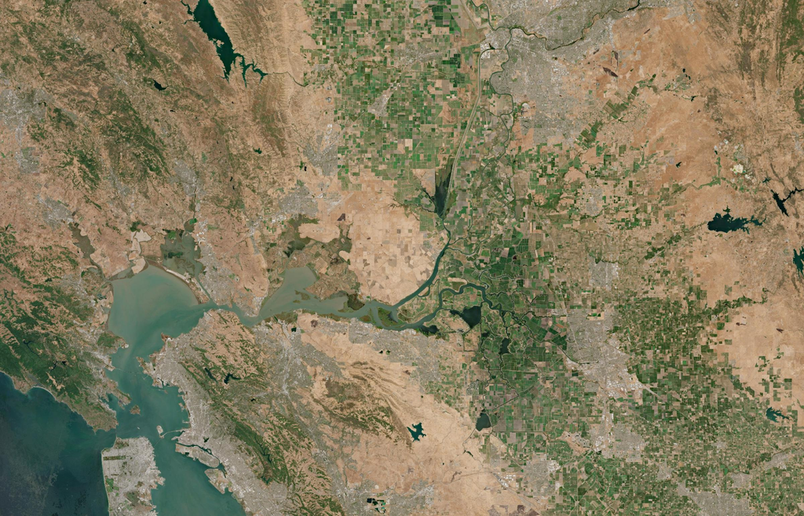

# Overview

In this presentation, we share our analysis of how to realize the Scenarios in the context of a changing climate, primarily by understanding the key actions and actors involved in their governance.

We’ll look at:

- **Data** and **Methods** for Examining Governance
- Key Implementation **Actions**
- Key **Actors**
- Next Steps
- Main **Takeaways**

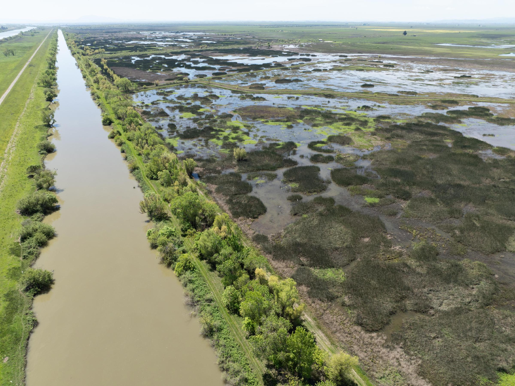

# How We Examined Governance

We used existing research and data on “adaptive governance” in the Delta to map out important:

- **Implementation Actions**
  - *Example: invest in levee maintenance.*
- **Actors**
  - *Example: the California Dept. of Water Resources*

Adaptive governance is an approach to environmental decision making that tries to address the uncertainties of climate change, “by creating institutions and processes that build in flexibility to respond to changes that cannot be fully anticipated.”[^5]

This means our focus is on how each scenario’s governance structure adapts to climate change. It’s a narrower slice of the broader answer on governance in the Delta, but this focus helpfully lines up with existing state priorities around climate resilience.

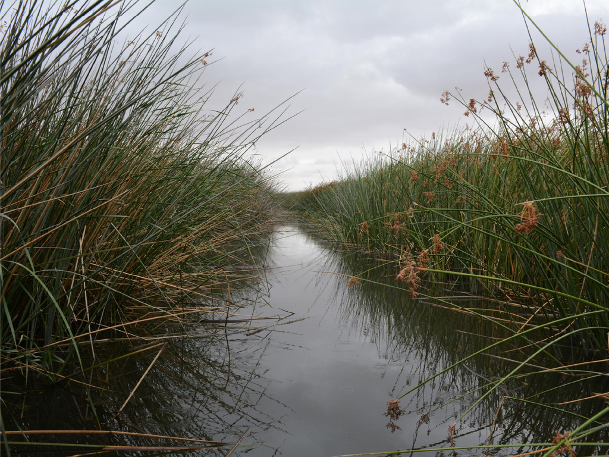

# Adaptation Plan

In 2025, the Delta Stewardship Council published the [“Adaptation Plan” (AP)](https://deltacouncil.ca.gov/pdf/delta-plan/2025-06-26-delta-adapts-adaptation-plan.pdf) to address the targets of adaptive governance in the California Delta.

We used this plan as a starting place to look at the key actions and actors for each scenario. This data is the focus of this presentation.

In addition, we leveraged survey data linking these key organizations to almost 600 other Delta organizations for a broader picture.[^6]

The Adaptation Plan has 4 “Strategic Areas” or themes to address Delta social-environmental management with the challenges of climate change. These include:

- Flood Risk Reduction (FL)
- Ecosystems (ECO)
- Agriculture (AG)
- Water Supply Reliability (WSR)

Under these four strategic areas, there are:

- 22 Adaptation Strategies with a total of:
  - 129 Implementation Actions
  - 10 lead and 67 partner organizations

[figure not shown]

Adaptation Plan (2025)

# Methodology: Alignment

- **Is this a core action?** Does this governance action help realize the JT Scenario?
- **Is this an intermediate action?** Does this action have elements that would help realize the JT scenario?
- **Is this a peripheral action?** Does this governance action potentially support the JT Scenario without direct engagement with scenario targets or mechanisms?
- **Is this a broadly beneficial action?** Does this action broadly support salinity management in the JT Scenario, but otherwise perform no contribution to the Scenario mechanisms?

Using this approach we determined a numeric score for each AP action under each Scenario.

The list of possible governance actions in the Adaptation Plan (AP) is not exhaustive:

- The AP likely does not cover every activity necessary to bring JT Scenarios to fruition.
- Nor does it cover every activity involved in managing salinity in the Delta.

In effect, actions that are considered relevant to Just Transitions either directly or indirectly engage with Scenario objectives, targets, or intent, and because the list of actions are derived from the Adaptation Plan, all actions fall within existing conceptions of climate change mitigation.

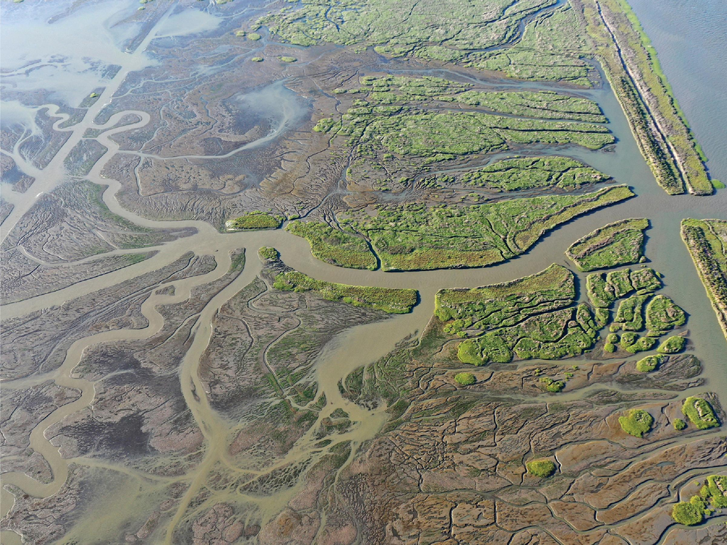

# Scenario Actions

We found that 110 of the 129 AP actions were relevant to Just Transitions.

This chart gives a basic picture of the complexity of the interrelations between the scenarios (left) and the AP actions (right).

[interactive chart not shown]

## Scenarios by Strategy Area

In this chart, each scenario is shown with its overall alignment with Adaptation Plan actions, grouped by the four strategy areas. The total score of each bar comprises a mix of both numbers of actions and strength of alignment. In other words, the larger the bar, the greater the number of weighted adaptive actions.

In interpreting this graph, it is important to remember that this primarily covers actions that provide resilience for salinity management in the Delta as it undergoes climate change, and the list of actions are non-exhaustive. Additionally, some caution should be exercised in its interpretation because we do not know the level of impact any one action might provide. (We’re essentially asking who is in the room, not how much they can do.) Nor can we say with certainty which actions are linchpins for any scenario. Our findings are only preliminary.

### Takeaways

[interactive chart not shown]

## Top Actions Overall

Across all scenarios, these are identified as the top actions.[^7] More important actions may be identified as the larger cells on the right.

The purpose of this chart is to facilitate exploring the actions on your own time, *not* to demonstrate the relative importance of any strategy area.

- There are more actions addressing the ecosystem due to the greater number of actions in New Green Watershed compared to other scenarios. New Green Watershed has the largest number of votes, and the Tunnel had the least.
- In the future, this information will be displayed in a different format!

### Takeaways

[interactive chart not shown]

## Eco Machine

There are 90 actions aligned with Eco Machine.

For the following slides, please pay attention to the changing scale for “score”.

The most important actions for this scenario derive from interventions in the ecosystem. Flood risk mitigation actions may also support Eco Machine (EM) priorities, but most of these appear as a third tier of interventions that are not directly performed in EM. This means that while a lot of flood risk mitigation actions might support EM, they are not integral to making this scenario possible. In addition, many ecosystem interventions also appear as supportive. Among the four main strategy areas, Water Supply Reliability and Agriculture had few directly pertinent interventions related to EM.

[interactive chart not shown]

### Unique Actions

This chart shows the core actions that are considered important for the scenario and which are absent in the top actions of all other scenarios. In other words, these are the actions that make the scenario unique. Core actions are categorized as actions that are directly performed, partly performed, or possibly a precondition for the scenario.

[interactive chart not shown]

## New Green Watershed

There are 108 actions aligned with New Green Watershed.

NGW has the most AP actions. Most of the top ranked actions for NGW prioritize ecosystem interventions, but also agriculture and flood risk reduction also play important roles in setting up this scenario for success.

[interactive chart not shown]

### Unique Actions

[interactive chart not shown]

## Tunnel

[interactive chart not shown]

## Bolster & Fortify

There are 71 actions aligned with Bolster & Fortify.

[interactive chart not shown]

### Unique Actions

[interactive chart not shown]

## Calling on Reserves

There are 74 actions aligned with Calling on Reserves.

[interactive chart not shown]

### Unique Actions

[interactive chart not shown]

## Increased Flows

There are 80 actions aligned with 30% Increased Tiered Outflow.

[interactive chart not shown]

## Actions Summary

| Scenarios | Total Actions | Unique Actions |
| --- | --- | --- |
| Eco Machine | 90 | 22 |
| New Green Watershed | 108 | 24 |
| Tunnel | 68 | 3 |
| Bolster & Fortify | 71 | 10 |
| Calling on Reserves | 74 | 20 |
| 30% Increased Tiered Outflow | 80 | 2 |

By and large, the kinds of adaptation actions suited to each Scenario is unsurprising because of our methodology.

The takeaway here is to note the overall diversity and complexity of each scenario, and how well each scenario aligns with opportunities to adapt to climate change.

The scenario with greatest number of adaptation actions, the most diverse strategies, and the scenario with the most unique actions is New Green Watershed. This suggests at least two takeaways: this scenario has the greatest number of tasks needed to see it through, but also has the greatest opportunities for mitigating the effects of climate change on salinity management.

Adaptive actions that regulate and support Delta agriculture are not centrally featured in most of Just Transitions. If shifting agricultural practices to support salinity management is of most concern to you, only two scenarios engage agriculture. This does not mean other scenarios have no impact on agriculture (for example, B&F performs levee maintenance). Rather, what this analysis suggests is that a Delta agriculture that is more resilient to climate change would additionally support salinity management. Investment in climate change resilient agriculture would not serve to advance the Tunnel, Calling on Reserves, Bolster & Fortify, or simply increasing flows.

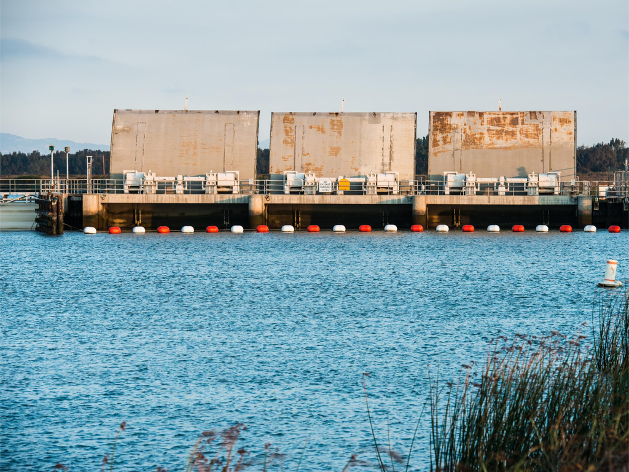

# Scenario Actors

The Adaptation Plan identifies two tiers of governance actors: lead and partner entities. These could include state agencies or regional governments, but also non-governmental organizations.

[interactive chart not shown]

## Lead Actor Types

Here we see how the lead actors are grouped by their type of organization. One takeaway is that the state is most important, but regional and local governments matter too.

[interactive chart not shown]

## All Actor Types

[interactive chart not shown]

## Actor Summary

| Scenario | Lead (n) | Lead Types | Partner (n) | Partner Types |
| --- | --- | --- | --- | --- |
| Eco Machine | 10 | 5 | 55 | 13 |
| New Green Watershed | 10 | 5 | 62 | 13 |
| Tunnel | 9 | 5 | 50 | 13 |
| Bolster & Fortify | 9 | 5 | 50 | 13 |
| Calling on Reserves | 9 | 5 | 57 | 13 |
| 30% Increased Tiered Outflow | 9 | 5 | 55 | 13 |

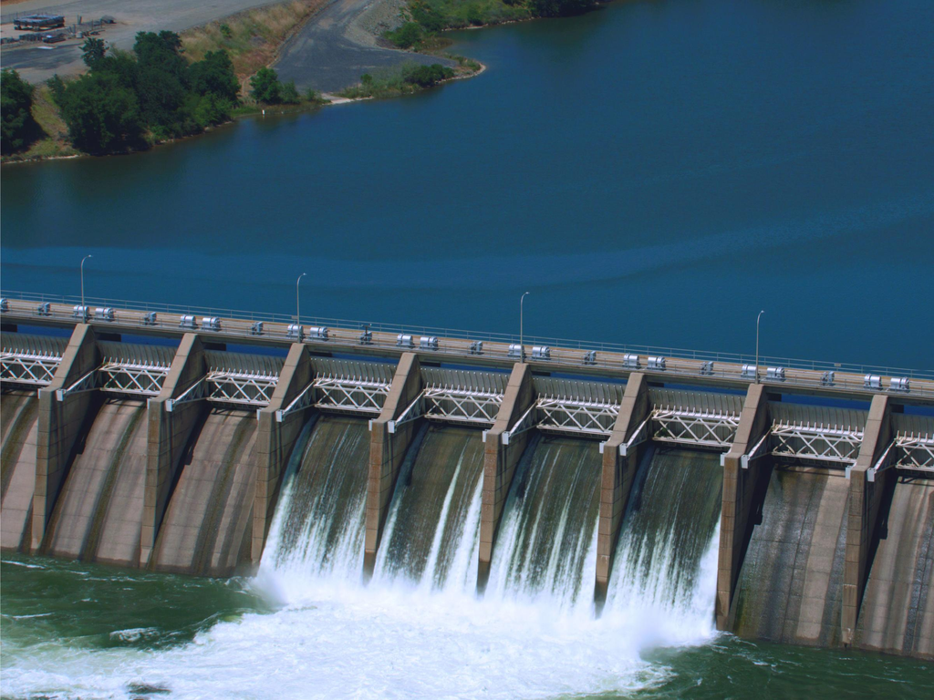

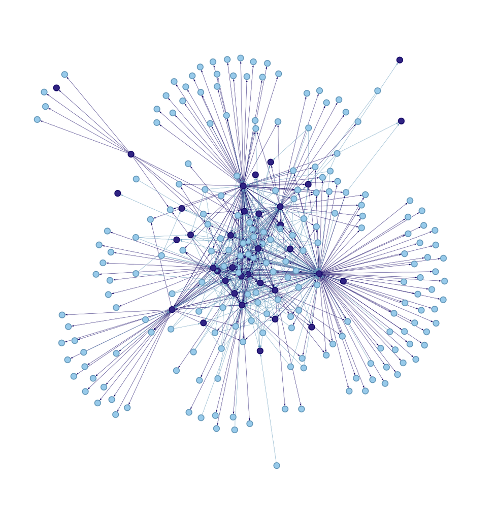